# Intermediate R for Social Science

Miruna Barnoschi

October 30<sup>th</sup>, 2019

# Overview

The goal of this intermediate R workshop is to start building the skills to (1) better utilize R Studio for social science research, (2) visualize data using the `ggplot2` package in R, (3) transform data using the `dplyr` package in R, and (4) use data visualization and transformation skills to explore social science data in a systematic way. The latter goals are first step into `tidyverse`, a suite of packages designed for data science that are immensely helpful when doing social science work.

# R Packages

```r
library(tinytex)
library(tidyverse)
library(readr)
library(ggplot2)
library(dplyr)
library(gridExtra)
```

# R Project

One best practice organizationally is to create a new R Project in an existing directory (presumably in the folder where the data is saved and the research notes/paper using that data is to be saved). Doing so saves time in terms of setting a working directory every time one works on this research project; more importantly, doing so makes replication easier.

# Dataset

We will look at a political science dataset that would be of interest to researchers in the subfields of comparative politics and international relations: “UCDP Battle-related Deaths Dataset Version 19.1” (https://ucdp.uu.se/downloads/).

# Read Data into R

```r
data <- read_csv("BattleDeaths_v19_1.csv")
```

# Filtering, Selecting, and Arranging Data

The war in Afghanistan has gone on from 2001 till today. Let’s examine more specifically battle deaths in Afghanistan from 2001 till today to get a better picture of the conflict in that location. We would do this by filtering the data by location, “Afghanistan”, and by year (2001-present) and selecting the variables associated with battle deaths (`bd_best`, `bd_low`, `bd_high`).

```r
data %>%
  filter(battle_location == "Afghanistan", year >= 2001) %>%
  arrange(year) %>%
  select(conflict_id, battle_location, year, bd_best, bd_low, bd_high)
```

```
## # A tibble: 14 x 6
##    conflict_id battle_location  year bd_best bd_low bd_high
##          <dbl> <chr>           <dbl>   <dbl>  <dbl>   <dbl>
##  1         333 Afghanistan      2001    2328   2217    7657
##  2       13692 Afghanistan      2001    1397   1388    2075
##  3         333 Afghanistan      2002      30     30      30
##  4         333 Afghanistan      2003      32     32      45
##  5         333 Afghanistan      2003     628    614     939
##  6         333 Afghanistan      2006      40     40      60
##  7         333 Afghanistan      2009      54     54      70
##  8         333 Afghanistan      2010      98     97     101
##  9         333 Afghanistan      2011      49     48      52
## 10         333 Afghanistan      2013      35     35      35
## 11       13637 Afghanistan      2015     674    625     865
## 12       13637 Afghanistan      2016    2141   2100    2544
## 13       13637 Afghanistan      2017    2795   2738    3009
## 14       13637 Afghanistan      2018    2842   2770    5149
```

```r
Afghanistandata <- data %>%
  filter(battle_location == "Afghanistan", year >= 2001) %>%
  arrange(year) %>%
  select(conflict_id, battle_location, year, bd_best, bd_low, bd_high)
```

# Summary Statistics

We can find the summary statistics (e.g. mean) of battle deaths in the subset of the dataset that focuses on the time period of the war in Afghanistan.

```r
summary(Afghanistandata$bd_best)
```

```
##    Min. 1st Qu.  Median    Mean 3rd Qu.    Max.
##   30.00   42.25  363.00  938.79 1955.00 2842.00
```

```r
summary(Afghanistandata$bd_low)
```

```
##    Min. 1st Qu.  Median    Mean 3rd Qu.    Max.
##    30.0    42.0   355.5   913.4  1922.0  2770.0
```

```r
summary(Afghanistandata$bd_high)
```

```
##    Min. 1st Qu.  Median    Mean 3rd Qu.    Max.
##      30      54     483    1616    2427    7657
```

```r
mean(Afghanistandata$bd_best)
```

```
## [1] 938.7857
```

```r
mean(Afghanistandata$bd_low)
```

```
## [1] 913.4286
```

```r
mean(Afghanistandata$bd_high)
```

```
## [1] 1616.5
```

# Finding Data

Let’s assume we do not want to limit ourselves to looking at data during the war in Afghanistan, but instead at data that involves Afghanistan (regardless if battles deaths occurred in Afghanistan per se). We could do so by filtering each variable with “Afghanistan”. Or, more simply, we could filter all the data for any variables with the string pattern, “Afghanistan”. There are numerous handy shortcuts in `dplyr` that can help us identify and find subsets of the data/specific values and information in the data.

```r
data %>%
  filter_all(any_vars(str_detect(., pattern = "Afghanistan"))) %>%
  arrange(year) %>%
  select(conflict_id, location_inc, side_a, side_a_2nd, side_b, side_b_2nd, year, battle_location, contains("bd"))
```

```
## # A tibble: 90 x 11
##    conflict_id location_inc side_a side_a_2nd side_b side_b_2nd  year
##          <dbl> <chr>        <chr>  <chr>      <chr>  <chr>      <dbl>
##  1         333 Afghanistan  Gover… Governmen… Jam'i… <NA>        1989
##  2         333 Afghanistan  Gover… Governmen… Hizb-… <NA>        1989
##  3         333 Afghanistan  Gover… Governmen… Mahaz… <NA>        1989
##  4         333 Afghanistan  Gover… Governmen… Hizb-… <NA>        1989
##  5         333 Afghanistan  Gover… Governmen… Hizb-… <NA>        1989
##  6         333 Afghanistan  Gover… <NA>       Jam'i… <NA>        1990
##  7         333 Afghanistan  Gover… <NA>       Hizb-… <NA>        1990
##  8         333 Afghanistan  Gover… <NA>       Hizb-… <NA>        1990
##  9         333 Afghanistan  Gover… <NA>       Hizb-… <NA>        1990
## 10         333 Afghanistan  Gover… <NA>       Milit… <NA>        1990
## # … with 80 more rows, and 4 more variables: battle_location <chr>,
## #   bd_best <dbl>, bd_low <dbl>, bd_high <dbl>
```

# Grouping Data

Suppose we wanted to know where and when the most amount of battle deaths occured. We could arrange the data to show the most battle death occurrences first. But, if we wanted to know where and when the most battle death occurred (in the aggregate), we should group by region/battle location and year and then tally up the battle deaths to see which region/battle location and year have the most battle death occurrences.

```r
data %>%
  arrange(desc(bd_best)) %>%
  select(conflict_id, battle_location, year, bd_best)
```

```
## # A tibble: 1,565 x 4
##    conflict_id battle_location                          year bd_best
##          <dbl> <chr>                                   <dbl>   <dbl>
##  1         299 Iraq, Lebanon, Syria                     2013   68614
##  2         299 Lebanon, Syria                           2014   54547
##  3         409 Eritrea, Ethiopia                        2000   50000
##  4         409 Eritrea, Ethiopia                        1999   47192
##  5         299 Syria, Turkey                            2012   39939
##  6         299 Jordan, Syria                            2015   33956
##  7         275 Ethiopia                                 1990   30633
##  8         299 Syria                                    2016   27207
##  9         333 Afghanistan, Pakistan                    2018   22837
## 10         371 Iraq, Kuwait, Philippines, Saudi Arabia  1991   21790
## # … with 1,555 more rows
```

```r
data %>%
  group_by(region) %>%
  tally(bd_best, sort = TRUE)
```

```
## # A tibble: 6 x 2
##   region      n
##    <dbl>  <dbl>
## 1      4 458105
## 2      2 444290
## 3      3 397851
## 4      1  58848
## 5      5  40464
## 6     NA   9324
```

```r
data %>%
  group_by(battle_location) %>%
  tally(bd_best, sort = TRUE)
```

```
## # A tibble: 171 x 2
##    battle_location            n
##    <chr>                  <dbl>
##  1 Afghanistan, Pakistan 150402
##  2 Eritrea, Ethiopia      98192
##  3 Ethiopia               88036
##  4 Syria                  77440
##  5 Iraq, Lebanon, Syria   68614
##  6 Afghanistan            66970
##  7 Lebanon, Syria         63974
##  8 Sri Lanka              57366
##  9 Syria, Turkey          40571
## 10 Sudan                  37398
## # … with 161 more rows
```

```r
data %>%
  group_by(year) %>%
  tally(bd_best, sort = TRUE)
```

```
## # A tibble: 30 x 2
##     year      n
##    <dbl>  <dbl>
##  1  2014 104555
##  2  2015  97328
##  3  2013  90596
##  4  2016  85799
##  5  1999  80578
##  6  1990  79681
##  7  2000  77357
##  8  1991  70236
##  9  2017  67101
## 10  2012  63257
## # … with 20 more rows
```

```r
data %>%
  group_by(region, year) %>%
  tally(bd_best, sort = TRUE)
```

```
## # A tibble: 152 x 3
## # Groups:   region [6]
##    region  year     n
##     <dbl> <dbl> <dbl>
##  1      2  2014 73051
##  2      2  2013 71684
##  3      2  2015 64595
##  4      4  1990 64585
##  5      4  1999 61216
##  6      4  2000 59700
##  7      2  2016 55376
##  8      2  2012 43734
##  9      2  2017 34621
## 10      4  1989 34546
## # … with 142 more rows
```

# Bar Charts

Suppose we wanted to know the distribution of the types of conflict this dataset contains (i.e. the distribution of the types of conflict that occurred during 1989-2018). We can create a bar chart to visualize this distribution.

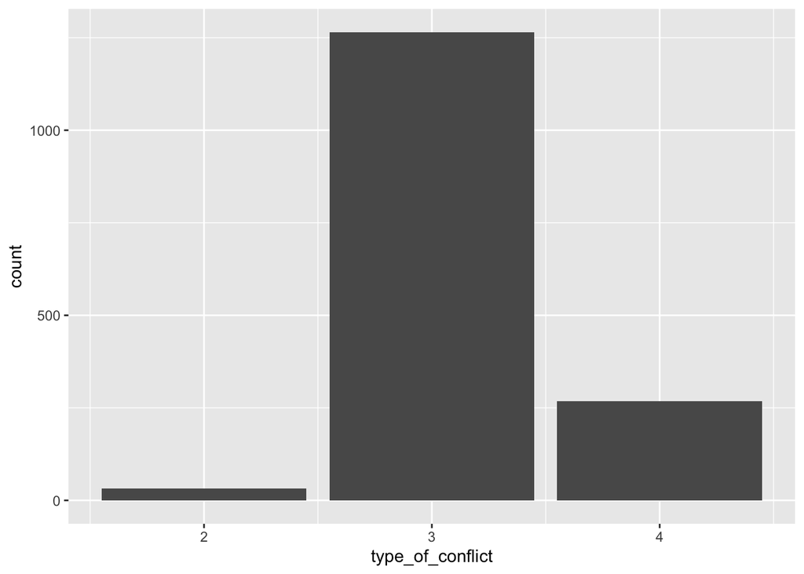

```r
data %>%
  ggplot(mapping = aes(x = type_of_conflict)) +
  geom_bar()
```

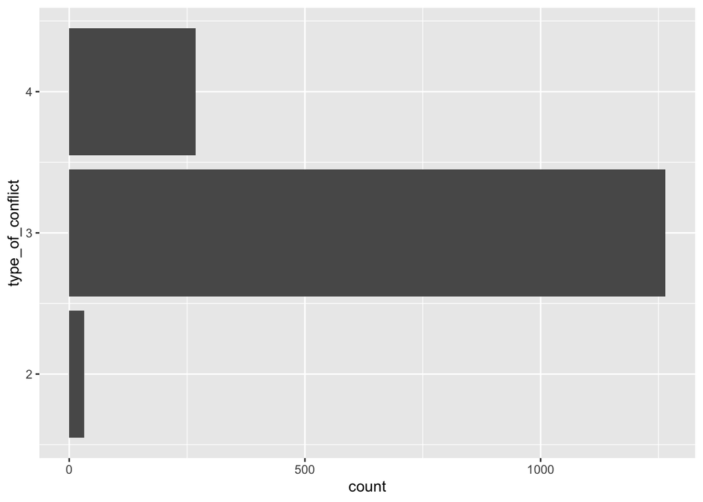

```r
data %>%
  ggplot(mapping = aes(x = type_of_conflict)) +
  geom_bar() +
  coord_flip()
```

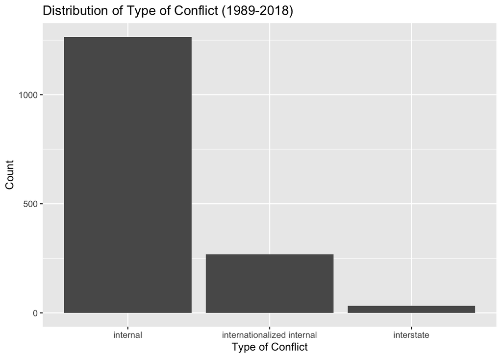

```r
data %>%
  mutate(type_of_conflict = case_when(
    type_of_conflict == "2" ~ "interstate",
    type_of_conflict == "3" ~ "internal",
    type_of_conflict == "4" ~ "internationalized internal")) %>%
  ggplot(mapping = aes(x = type_of_conflict)) +
  geom_bar() +
  ggtitle("Distribution of Type of Conflict (1989-2018)") +
  xlab("Type of Conflict") + ylab("Count")
```

# Scatter Plots

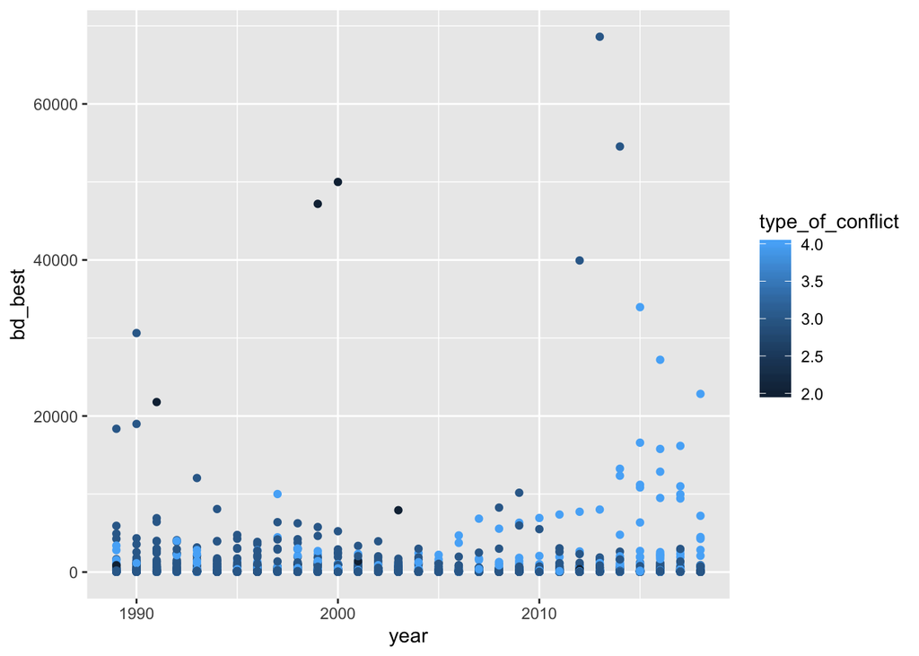

```r
data %>%
  ggplot(mapping = aes(x = year, y = bd_best, color = type_of_conflict)) +
  geom_point()
```

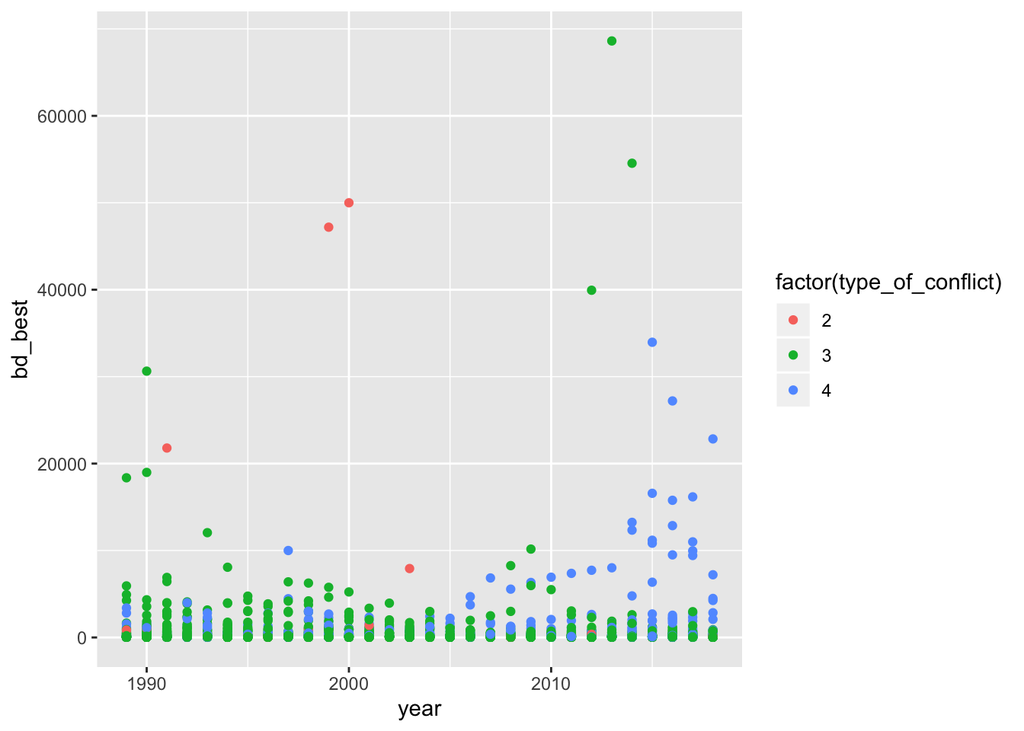

```r
# Factor `type_of_conflict`

data %>%
  ggplot(mapping = aes(x = year, y = bd_best, colour = factor(type_of_conflict))) +
  geom_point()
```

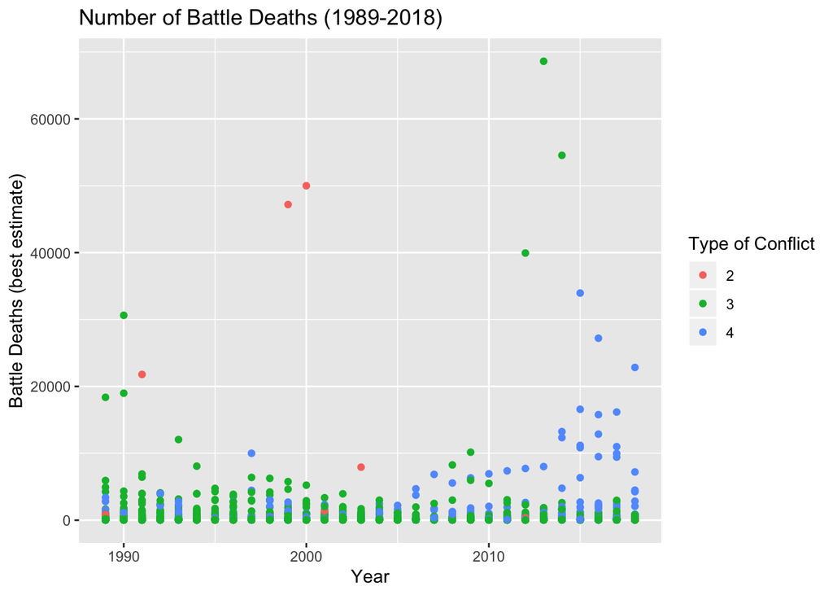

```r
data %>%
  ggplot(mapping = aes(x = year, y = bd_best, color = factor(type_of_conflict))) +
  geom_point() +
  ggtitle("Number of Battle Deaths (1989-2018)") +
  labs(x = "Year", y = "Battle Deaths (best estimate)", color = "Type of Conflict")
```

Suppose we wanted to know the number of battle deaths across time in Iraq and determine the trend. We can create a scatterplot showing the battle deaths across time for Iraq (even subset the points by conflict) and add a trend line.

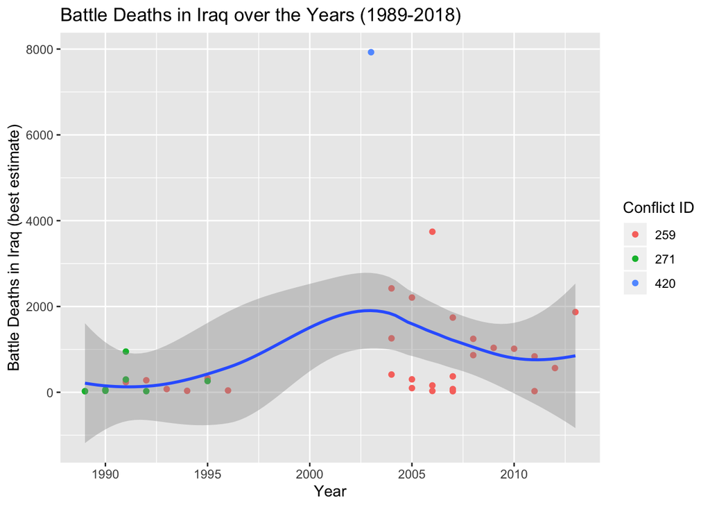

```r
data %>%
  filter(battle_location == "Iraq") %>%
  arrange(conflict_id, year) %>%
  select(conflict_id, battle_location, year, bd_best) %>%
  ggplot(mapping = aes(x = year, y = bd_best)) +
  geom_point(aes(color = factor(conflict_id))) +
  geom_smooth() +
  ggtitle("Battle Deaths in Iraq over the Years (1989-2018)") +
  labs(x = "Year", y = "Battle Deaths in Iraq (best estimate)", colour = "Conflict ID")
```